# Wilcoxon Signed Rank Test in R

[Nathaniel E. Helwig](http://stat.umn.edu/~helwig) Department of Psychology & School of Statistics University of Minnesota

Copyright © January 30, 2026

# 1 One-Sample Location Problem

## 1.1 Overview

The *one-sample* location problem refers to the following situations:

- Paired-replicates data: $(X_i, Y_i)$ are bivariate independent samples
- One-sample data: $Z_i$ are univariate independent samples

We want to make inference about:

- Paired-replicates data: difference in location (treatment effect)
- One-sample data: single population’s location

Note: for paired replicates data, we analyze the difference scores: $Z_{i} = X_{i} - Y_{i}$.

## 1.2 Symmetry Assumption

For one-sample data, we assume that $F$ is symmetric around $\theta$ (median).

- symmetric: $F(\theta - b) + F(\theta + b) = 1 \quad \forall b$
- left-skew: $F(\theta + b) \geq 1 - F(\theta - b) \quad \forall b > 0$
- right-skew: $F(\theta + b) \leq 1 - F(\theta - b) \quad \forall b > 0$

For paired replicates data, we assume *exchangeability* of $X$ and $Y$

- Definition: $(X,Y)$ and $(Y,X)$ are exchangeable if they have the same distribution
- Implies $F_{X}\equiv F_{Y}$ and $F_{X|Y}\equiv F_{Y|X}$ and $F_{Z}\equiv F_{-Z}$ with $Z=X-Y$
- $F_{Z}\equiv F_{-Z}$ implies that $F_{Z}$ is symmetric about 0

More generally, if components of $(X+\theta,Y)$ are exchangeable, then

- $Z-\theta = X-(Y+\theta)$ has the same distribution as $\theta-Z = (Y+\theta)-X$
- $F_{Z}$ is symmetric about $\theta$

## 1.3 Null and Alternative Hypotheses

The null hypothesis about $\theta$ (common median) is
$$H_{0}: \theta = \theta_{0}$$
and we could have one of three alternative hypotheses:

- $H_{1}: \theta > \theta_{0}$ Greater Than
- $H_{1}: \theta < \theta_{0}$ Less Than
- $H_{1}: \theta \neq \theta_{0}$ Two-Sided

# 2 Methodological Details

## 2.1 Test Statistic

Let $R_{i}$ for $i\in\{1,\ldots,n\}$ denote the ranks of $|Z_{i} - \theta_{0}|$.

Defining the indicator variable
$$\psi_{i} = \left\{\begin{matrix} 1 & \mbox{if }
Z_{i}-\theta_{0}>0\\ 0 & \mbox{if } Z_{i}-\theta_{0}<0
\end{matrix}\right.$$
the Wilcoxon signed rank test statistic $T^{+}$ is defined as
$$T^{+} = \sum_{i=1}^{n} R_{i}\psi_{i}$$
where $R_{i}\psi_{i}$ is the *positive signed rank* of $Z_{i}-\theta_{0}$

## 2.2 Null Distribution

Assume no ties, let $B = \sum_{i=1}^n \psi_i$ denote the number of $Z_{i} - \theta_{0}$ values that are greater than $0$, and let $r_{1} < r_{2} < \cdots < r_{B}$ denote the (ordered) ranks of the positive $Z_{i} - \theta_{0}$ values.

- The test statistics can be written $T^{+} = \sum_{i=1}^{B} r_{i}$ if $B \geq 1$
- Note that $B \in \{0, 1, \ldots, n\}$ and $T^{+} = 0$ if $B = 0$

Under $H_{0}: \theta = \theta_{0}$ we have that $Z_{i} - \theta_{0} \sim \tilde{F}_{i}$, which is continuous and symmetric around $0$.

All $2^{n}$ possible outcomes for $(r_{1},r_{2},\ldots, r_{B})$ occur with equal probability.

- For given $n$, form all $2^{n}$ possible outcomes with corresponding $T^{+}$
- Each outcome has probability $\frac{1}{2^{n}}$ under $H_{0}$

Suppose we have $n=3$ observations $(Z_{1},Z_{2},Z_{3})$ with no ties.

The $2^{3}=8$ possible outcomes for $(r_{1},r_{2},\ldots, r_{B})$ are:

| $B$ | $(r_{1},r_{2},\ldots, r_{B})$ | $T^{+}=\sum_{i=1}^{B}r_{i}$ | Probability under $H_{0}$ |
| --- | --- | --- | --- |
| 0 |  | 0 | $1/8$ |
| 1 | $(1)$ | 1 | $1/8$ |
| 1 | $(2)$ | 2 | $1/8$ |
| 1 | $(3)$ | 3 | $1/8$ |
| 2 | $(1, 2)$ | 3 | $1/8$ |
| 2 | $(1, 3)$ | 4 | $1/8$ |
| 2 | $(2, 3)$ | 5 | $1/8$ |
| 3 | $(1, 2, 3)$ | 6 | $1/8$ |

Example probability calculation: $P(T^{+}<2) = \sum_{i=0}^{1} P(T^{+}=i) = 0.25$

## 2.3 Statistical Inference

### 2.3.1 Exact Test

One-Sided Test (Greater Than)

- $H_{0}: \theta = \theta_{0}$ versus $H_{1}: \theta > \theta_{0}$
- Reject $H_{0}$ if $T^{+}\geq t_{1-\alpha}$ where $P(T^{+}>t_{1-\alpha})=\alpha$
- P-Value: $p = \frac{1}{2^n} \sum_{j=1}^{2^n} I(T_j^+ \geq T_{\mathrm{obs}}^+)$

One-Sided Test (Less Than)

- $H_{0}: \theta = \theta_{0}$ versus $H_{1}: \theta < \theta_{0}$
- Reject $H_{0}$ if $T^{+}\leq t_{\alpha}$ where $P(T^{+}<t_{\alpha})=\alpha$
- P-Value: $p = \frac{1}{2^n} \sum_{j=1}^{2^n} I(T_j^+ \leq T_{\mathrm{obs}}^+)$

Two-Sided Test

- $H_{0}: \theta = \theta_{0}$ versus $H_{1}: \theta \neq \theta_{0}$
- Reject $H_{0}$ if $T^{+} \leq t_{\alpha/2}$ OR $T^{+}\geq t_{1-\alpha/2}$
- P-Value: $p = \frac{1}{2^n} \sum_{j=1}^{2^n} I(|T_j^+| \geq |T_{\mathrm{obs}}^+|)$

Note: the null distribution is symmetric so $t_{\alpha/2} = \frac{n(n+1)}{2} - t_{1-\alpha/2}$

### 2.3.2 Large Sample Approximation

Under $H_{0}$, the expected value and variance of $T^{+}$ are

- $E(T^{+}) = \frac{n(n+1)}{4}$
- $V(T^{+}) = \frac{n(n+1)(2n+1)}{24}$

We can create a standardized test statistic $T^{*}$ of the form
$$T^{*} = \frac{T^{+}-E(T^{+})}{\sqrt{V(T^{+})}}$$
which asymptotically follows a $\mathrm{N}(0,1)$ distribution.

Derivation of Large Sample Approximation:

Note that we have $T^{+}=\sum_{i=1}^{n}U_{i}$ where

- $U_{i} = R_{i}\psi_{i}$ are independent variables for $i=1,\ldots,n$
- $P(U_{i}=i)=P(U_{i}=0) = 1/2$

Using the independence of the $U_{i}$ variables we have

- $E(T^{+}) = \sum_{i=1}^{n}E(U_{i})$
- $V(T^{+}) = \sum_{i=1}^{n}V(U_{i})$

Using the distribution of $U_{i}$ we have

- $E(U_{i})=i\frac{1}{2}+0\frac{1}{2}=\frac{i}{2}$ $\Longrightarrow$ $E(T^{+})=\frac{1}{2}\sum_{i=1}^{n}i=\frac{n(n+1)}{4}$
- $V(U_{i})=E(U_{i}^{2})-[E(U_{i})]^{2} = \frac{i^{2}}{2}-\frac{i^{2}}{4} = \frac{i^{2}}{4}$ $\Longrightarrow$ $V(T^{+})=\frac{1}{4}\sum_{i=1}^{n}i^{2}=\frac{n(n+1)(2n+1)}{24}$

Note: we are applying Gauss’s summation of integers and squares rules.

### 2.3.3 Handling Zeros and Ties

If $Z_{i}=\theta_{0}$, then discard $Z_{i}$ and redefine $\tilde{n}$ as the number of observations that do not equal $\theta_{0}$.

If $Z_{i}=Z_{j}$ for two (non-zero) observations, then use the average ranking procedure to handle ties.

- $T^{+}$ is calculated in same fashion (using average ranks)
- No longer an exact level $\alpha$ test
- Need to adjust variance term for large sample approximation

## 2.4 Estimating Location

To estimate the median (or median difference) $\theta$, first form the $M=n(n+1)/2$ average values
$$W_{ij} = (Z_{i}+Z_{j})/2$$
for $i\leq j = 1,\ldots,n$, which are known as *Walsh averages*

The *Hodges-Lehman* estimate of $\theta$ corresponding to Wilcoxon’s signed rank test is
$$\hat{\theta} = \mbox{median}(W_{ij}; \ i\leq j = 1,\ldots,n)$$
which is the median of the Walsh averages.

## 2.5 Confidence Intervals

Define the following terms

- $M=n(n+1)/2$ is the number of Walsh averages
- $W^{(1)}\leq W^{(2)}\leq \cdots \leq W^{(M)}$ are the ordered Walsh averages
- $t_{1-\alpha/2}$ is the critical value such that $P(T^{+}>t_{1-\alpha/2})=\alpha/2$ under $H_{0}$
- $C_{\alpha/2} = M + 1 - t_{1-\alpha/2}$ is the transformed critical value
- $(\theta_{L}, \theta_{U})$ are the lower and upper bounds of the interval

A symmetric $(1-\alpha)100$% confidence interval for $\theta$ is given by

- $\theta_{L} = W^{(C_{\alpha/2})}$
- $\theta_{U} = W^{(M+1-C_{\alpha/2})}$

An asymmetric $(1-\alpha)100$% upper confidence bound for $\theta$ is

- $\theta_{L} = -\infty$
- $\theta_{U} = W^{(M+1-C_{\alpha})}$

An asymmetric $(1-\alpha)100$% lower confidence bound for $\theta$ is

- $\theta_{L} = W^{(C_{\alpha})}$
- $\theta_{U} = \infty$

# 3 Example

## 3.1 Data and Problem

### 3.1.1 Overview of Problem

Example 3.1 from *Nonparametric Statistical Methods, 3rd Ed*

Nine psychiatric patients were treated with a tranquilizer drug.

$X$ and $Y$ are pre- and post-treatment Hamilton Depression Scale Factor IV scores

- Higher scores correspond to more suicidal tendencies

Want to test if the tranquilizer significantly reduced suicidal tendencies

- $H_{0}: \theta=0$ versus $H_{1}: \theta>0$.
- $\theta$ is median of $Z = X - Y$

### 3.1.2 Data Table

Table 3.1 The Hamilton Depression Scale Factor IV Values

| Patient $i$ | $X_{i}$ | $Y_{i}$ |
| --- | --- | --- |
| 1 | 1.83 | 0.878 |
| 2 | 0.50 | 0.647 |
| 3 | 1.62 | 0.598 |
| 4 | 2.48 | 2.050 |
| 5 | 1.68 | 1.060 |
| 6 | 1.88 | 1.290 |
| 7 | 1.55 | 1.060 |
| 8 | 3.06 | 3.140 |
| 9 | 1.30 | 1.290 |

Source: D. S. Salsburg (1970).

## 3.2 By Hand

### 3.2.1 Differences, Ranks, and Signs

| Patient $i$ | $X_{i}$ | $Y_{i}$ | $Z_{i}$ | $R_{i}$ | $\psi_{i}$ |
| --- | --- | --- | --- | --- | --- |
| 1 | 1.83 | 0.878 | 0.952 | 8 | 1 |
| 2 | 0.50 | 0.647 | -0.147 | 3 | 0 |
| 3 | 1.62 | 0.598 | 1.022 | 9 | 1 |
| 4 | 2.48 | 2.050 | 0.430 | 4 | 1 |
| 5 | 1.68 | 1.060 | 0.620 | 7 | 1 |
| 6 | 1.88 | 1.290 | 0.590 | 6 | 1 |
| 7 | 1.55 | 1.060 | 0.490 | 5 | 1 |
| 8 | 3.06 | 3.140 | -0.080 | 2 | 0 |
| 9 | 1.30 | 1.290 | 0.010 | 1 | 1 |

*Note*. $Z_{i}=X_{i}-Y_{i}$ and $R_{i}$ is rank of $|Z_{i}|$

### 3.2.2 Test Statistic

The test statistic just sums the $R_i$ for the observations where $\psi_i$ equals one:

- $T^{+}=\sum_{i=1}^{n} R_{i}\psi_{i} = 40$

Note: computing the p-value would require calculating all $2^n = 512$ possible versions of the test statistic. The different versions of the test statistic correspond to all possible signings of the $Z_i$:

- there are two possibilities ($Z_i$ is either negative or positive)
- there are $n$ independent observations

## 3.3 Using R

### 3.3.1 Input Data

Load Data:

```r
x <- c(1.83, 0.50, 1.62, 2.48, 1.68, 1.88, 1.55, 3.06, 1.30)
y <- c(0.878, 0.647, 0.598, 2.050, 1.060, 1.290, 1.060, 3.140, 1.290)
```

### 3.3.2 Wilcoxon’s Signed Rank Test (stats package)

Wilcoxon’s Signed Rank Test using **stats** package:

```r
wilcox.test(x, y, alternative = "greater", paired = TRUE, conf.int = TRUE)
```

```
##
##  Wilcoxon signed rank exact test
##
## data:  x and y
## V = 40, p-value = 0.01953
## alternative hypothesis: true location shift is greater than 0
## 95 percent confidence interval:
##  0.175   Inf
## sample estimates:
## (pseudo)median
##           0.46
```

### 3.3.3 Wilcoxon’s Signed Rank Test (nptest package)

Wilcoxon’s Signed Rank Test using **nptest** package:

```r
library(nptest)
mod <- np.loc.test(x, y, alternative = "greater", paired = TRUE, median.test = TRUE)
mod
```

```
##
## Nonparametric Location Test (Paired Wilcoxon Signed Rank Test)
## alternative hypothesis: true median of differences is greater than 0
## t = 2.0732,  p-value = 0.0195
## sample estimate:
## (pseudo)median of the differences
##                              0.46
```

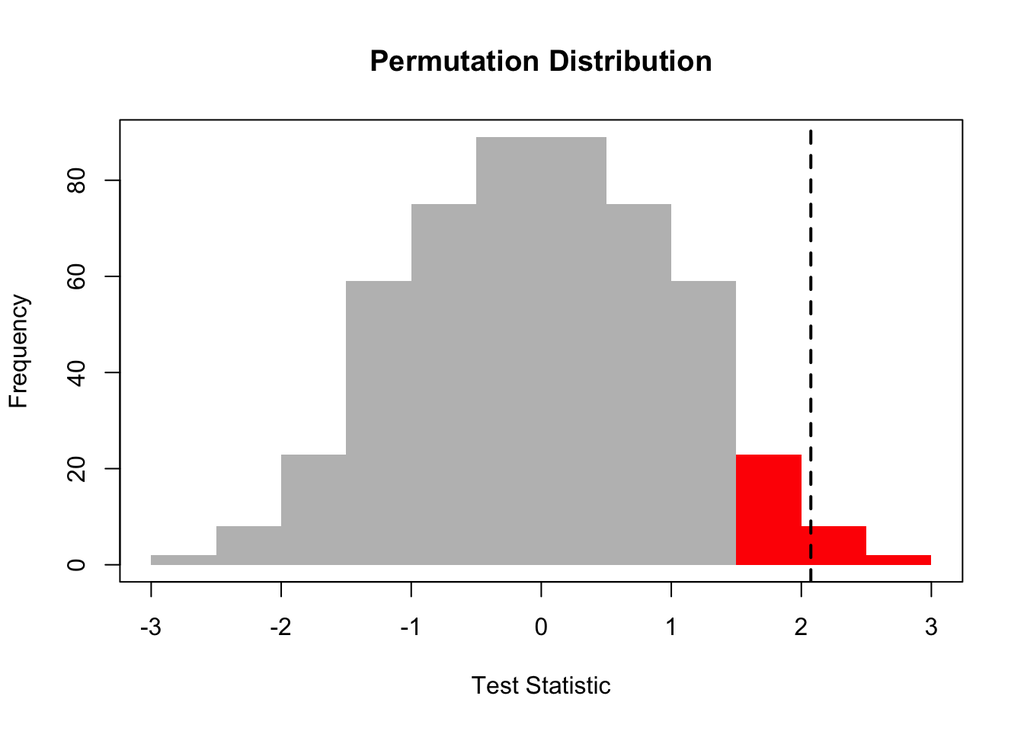

```r
plot(mod)
```

To get the confidence lower bound

```r
z <- x - y                                           # difference score
n <- length(z)                                       # number of observations
temp <- outer(z, z, "+") / 2                         # all pairwise averages
owa <- sort(temp[lower.tri(temp, diag = T)])         # ordered walsh averages
M <- length(owa)                                     # 9 * 10 / 2 = 45
critval <- quantile(mod$perm.dist, probs = 0.95)     # std crit val
expval <- n * (n + 1) / 4                            # expected value (under H0)
varval <- n * (n + 1) * (2 * n + 1) / 24             # variance (under H0)
critval <- critval * sqrt(varval) + expval           # raw crit val
c(owa[M - critval], Inf)                             # 95% lower bound
```

```
## [1] 0.175   Inf
```

### 3.3.4 Student’s t test (stats package)

Student’s $t$ test:

```r
t.test(x, y, alternative = "greater", paired = TRUE)
```

```
##
##  Paired t-test
##
## data:  x and y
## t = 3.0354, df = 8, p-value = 0.008088
## alternative hypothesis: true mean difference is greater than 0
## 95 percent confidence interval:
##  0.1673028       Inf
## sample estimates:
## mean difference
##       0.4318889
```

### 3.3.5 Student’s t test (nptest package)

Student’s $t$ test:

```r
mod <- np.loc.test(x, y, alternative = "greater", paired = TRUE)
mod
```

```
##
## Nonparametric Location Test (Paired t-test)
## alternative hypothesis: true difference of means is greater than 0
## t = 3.0354,  p-value = 0.0137
## sample estimate:
## mean of the differences
##               0.4318889
```

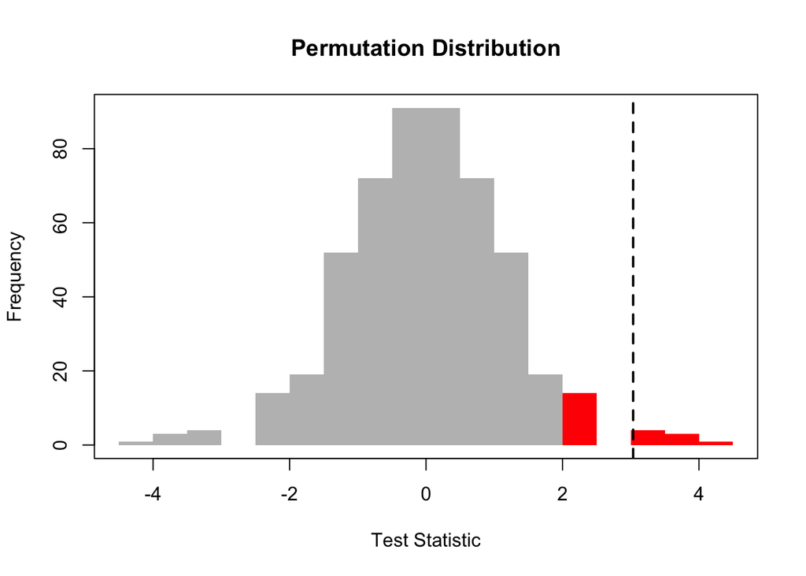

```r
plot(mod)
```